# Лабораторна робота № 6. Базові операції з цифровими зображеннями, аналіз каналів та колірні простори

### Мета: Опанувати практичні навички програмного представлення цифрових растрових зображень як багатовимірних масивів даних у середовищі Python, дослідити відмінності структур колірного кодування бібліотек OpenCV, Pillow та Matplotlib, вивчити математичні засади функціонування колірних просторів RGB, HSV та CIELab, а також реалізувати алгоритми декомпозиції колірних каналів і порогової сегментації об'єктів за спектральними характеристиками.

#### *Варіант 2 (№ 22 у списку: $22 - 20 = 2$)*

### Виконав: Яцентюк Євгеній, група: КІ-24-1

[**GitHub**](https://github.com/kefir4ikk)

## 1. Імпорт бібліотек та налаштування стилю відображення

```python
import os
import json
import cv2
import numpy as np
import matplotlib.pyplot as plt
from PIL import Image

os.makedirs("figures", exist_ok=True)
os.makedirs("data", exist_ok=True)

plt.rcParams['font.family'] = 'DejaVu Sans'
plt.rcParams['axes.edgecolor'] = '#2b2b2b'
plt.rcParams['axes.linewidth'] = 1.0
plt.rcParams['grid.color'] = '#cccccc'
plt.rcParams['grid.linestyle'] = '--'
plt.rcParams['grid.alpha'] = 0.6

import matplotlib
print(f"NumPy: {np.__version__} | OpenCV: {cv2.__version__} | Pillow: {Image.__version__} | Matplotlib: {matplotlib.__version__}")
```

```
NumPy: 2.5.4 | OpenCV: 5.0.0 | Pillow: 13.0.0 | Matplotlib: 3.11.2
```

## 2. Параметри варіанта 2 та постановка завдання

**Індивідуальне завдання (варіант 2):**

| Цільовий колірний об'єкт | Нижній поріг $[H_{min},S_{min},V_{min}]$ | Верхній поріг $[H_{max},S_{max},V_{max}]$ | Сфера застосування |
| --- | --- | --- | --- |
| Темно-червоний (Red Part 2) | $[170,\,120,\,100]$ | $[180,\,255,\,255]$ | Медичний аналіз крововиливів на знімках |

Усі межі задано для 8-бітної шкали OpenCV: $H\in[0,179]$ ($H_{cv}=H^\circ/2$), $S,V\in[0,255]$. Верхня межа $H_{max}=180$ у `inRange` рівнозначна $179$, оскільки значення $180$ у `uint8`-кодуванні не трапляється. Діапазон $H_{cv}\in[170,179]$ відповідає кутам $340^\circ\ldots358^\circ$ — «малиново-червоному» сектору поблизу межі $0^\circ/360^\circ$ з боку фіолетового. **Чистий червоний колір ($H=0^\circ$) належить іншому сектору (Red Part 1, $[0,10]$) і в діапазон цього варіанта не потрапляє**, що слід підтвердити експериментально.

**Тестова сцена.** Крім шести базових фігур еталонного прикладу, сцена $400\times600$ містить цільові та «складні негативні» об'єкти, кожен з яких перевіряє окрему межу порога:

| Об'єкт | Колір (BGR) | Очікувано | Що перевіряє |
| --- | --- | --- | --- |
| Темно-червоний прямокутник | $(46,20,175)$ | вибрано | ціль, $H=175$ |
| Малиново-червоний еліпс | $(60,20,230)$ | вибрано | ціль, інша яскравість $V=230$ |
| Чистий червоний круг | $(30,30,230)$ | **не вибрано** | $H=0$: інший сектор червоного |
| Бордовий прямокутник | $(20,10,80)$ | **не вибрано** | $H$ у діапазоні, але $V=80<V_{min}$ |
| Блідо-рожевий круг | $(160,150,220)$ | **не вибрано** | $H$ у діапазоні, але $S\approx81<S_{min}$ |
| Пурпурний трикутник | $(200,30,200)$ | **не вибрано** | $H=150$ поза діапазоном |
| Помаранчевий, жовтий, зелений, синій | — | не вибрано | інші ділянки кола тонів |

Фігури малюються без згладжування (`cv2.LINE_8`), тому для кожної відома точна маска, і якість сегментації вимірюється кількісно.

**Формули перетворень** (канали нормовано до $[0,1]$):

$$Y=0.299R+0.587G+0.114B;\qquad V=\max(R,G,B),\quad S=1-\frac{\min(R,G,B)}{V},\quad H=60^\circ\cdot\Big(\tfrac{G-B}{V-\min}\bmod6\Big)\ \text{для}\ V=R\ \text{(аналогічно для}\ G,B).$$

$$M[y,x]=255\ \text{якщо}\ H_{min}\le H\le H_{max}\ \wedge\ S_{min}\le S\le S_{max}\ \wedge\ V_{min}\le V\le V_{max},\ \text{інакше}\ 0.$$

Для CIELab: лінеаризація sRGB $\to$ $XYZ$ (D65) $\to$ $L^*=116f(Y/Y_n)-16$, $a^*=500\,[f(X/X_n)-f(Y/Y_n)]$, $b^*=200\,[f(Y/Y_n)-f(Z/Z_n)]$, де $f(t)=\sqrt[3]{t}$ при $t>0.008856$. У 8-бітному OpenCV: $L^*\cdot255/100$, $a^*+128$, $b^*+128$.

```python
# --- Параметри варіанта 2
LOWER_RED2 = np.array([170, 120, 100], dtype=np.uint8)
UPPER_RED2 = np.array([180, 255, 255], dtype=np.uint8)
# Доповнювальний сектор Red Part 1 (для порівняння; НЕ належить варіанту 2)
LOWER_RED1 = np.array([0, 120, 100], dtype=np.uint8)
UPPER_RED1 = np.array([10, 255, 255], dtype=np.uint8)

H_IMG, W_IMG, BG_GRAY = 400, 600, 180

# --- Опис фігур тестової сцени: (назва, колір BGR, тип, параметри, очікується в масці варіанта 2)
SHAPES = [
    dict(name="Чистий червоний (круг)",      bgr=(30, 30, 230),   kind="circle",   p=((60, 100), 45),            target=False),
    dict(name="Темно-червоний (прямокутник)", bgr=(46, 20, 175),   kind="rect",     p=((135, 55), (225, 145)),    target=True),
    dict(name="Малиново-червоний (еліпс)",   bgr=(60, 20, 230),   kind="ellipse",  p=((300, 100), (50, 40)),     target=True),
    dict(name="Бордовий, V<100 (прямокутник)", bgr=(20, 10, 80),   kind="rect",     p=((375, 55), (465, 145)),    target=False),
    dict(name="Блідо-рожевий, S<120 (круг)",  bgr=(160, 150, 220), kind="circle",   p=((540, 100), 45),           target=False),
    dict(name="Пурпурний (трикутник)",       bgr=(200, 30, 200),  kind="triangle", p=([(15, 345), (105, 345), (60, 255)],), target=False),
    dict(name="Помаранчевий (еліпс)",        bgr=(20, 130, 245),  kind="ellipse",  p=((180, 300), (50, 40)),     target=False),
    dict(name="Жовтий (прямокутник)",        bgr=(30, 230, 240),  kind="rect",     p=((255, 255), (345, 345)),   target=False),
    dict(name="Зелений (прямокутник)",       bgr=(30, 220, 30),   kind="rect",     p=((375, 255), (465, 345)),   target=False),
    dict(name="Синій (круг)",                bgr=(230, 40, 40),   kind="circle",   p=((540, 300), 45),           target=False),
]

def draw_shape(canvas, sh, color):
    """Малювання фігури без згладжування (cv2.LINE_8): точна маска для кожної фігури."""
    if sh["kind"] == "circle":
        cv2.circle(canvas, sh["p"][0], sh["p"][1], color, -1)
    elif sh["kind"] == "rect":
        cv2.rectangle(canvas, sh["p"][0], sh["p"][1], color, -1)
    elif sh["kind"] == "ellipse":
        cv2.ellipse(canvas, sh["p"][0], sh["p"][1], 0, 0, 360, color, -1)
    elif sh["kind"] == "triangle":
        cv2.fillPoly(canvas, [np.array(sh["p"][0], np.int32)], color)

def generate_synthetic_scene():
    """Калібрувальна сцена BGR 400x600: фігури на нейтральному сірому тлі + маска кожної фігури."""
    img = np.full((H_IMG, W_IMG, 3), BG_GRAY, dtype=np.uint8)
    masks = []
    for sh in SHAPES:
        draw_shape(img, sh, sh["bgr"])
        m = np.zeros((H_IMG, W_IMG), np.uint8)
        draw_shape(m, sh, 255)
        masks.append(m)
    return img, masks

test_image_bgr, shape_masks = generate_synthetic_scene()
assert cv2.imwrite("data/test_image.png", test_image_bgr)
gt_target = np.zeros((H_IMG, W_IMG), np.uint8)
for sh, m in zip(SHAPES, shape_masks):
    if sh["target"]:
        gt_target |= m
print(f"Сцену згенеровано та збережено: data/test_image.png; фігур: {len(SHAPES)}, з них цільових: {sum(s['target'] for s in SHAPES)}")
```

```
Сцену згенеровано та збережено: data/test_image.png; фігур: 10, з них цільових: 2
```

## 3. Структура тензора зображення, порівняння BGR / RGB та декомпозиція каналів

Зображення завантажується з диска двома бібліотеками. OpenCV повертає масив у порядку каналів **BGR**, Pillow та Matplotlib використовують **RGB**. Для демонстрації інверсії BGR-масив передається в `plt.imshow` без перетворення. Канали розділяються `cv2.split()` та зрізами NumPy, результати порівнюються. Напівтонове зображення за ITU-R BT.601 порівнюється з ручним розрахунком.

```
==================================================================================
МЕТРИКИ ТА СТРУКТУРНІ ХАРАКТЕРИСТИКИ ТЕНЗОРА ЗОБРАЖЕННЯ
==================================================================================
Роздільна здатність (Shape):     висота H = 400 px, ширина W = 600 px; кількість каналів: 3
Загальна кількість пікселів:     240,000 px
Тип даних елементів:             uint8 (діапазон 0..255), 256 градацій на канал
Обсяг пам'яті (img.nbytes):      720,000 байт = 703.12 КіБ; розмір PNG на диску: 9,288 байт (стиснення 77.5:1)
Pillow:                          mode = RGB, size = (600, 400) (ширина, висота)
Піксель червоного круга (100,60):   OpenCV BGR = (30, 30, 230); після cvtColor RGB = (230, 30, 30)
  без перетворення у Matplotlib цей піксель інтерпретується як RGB = (30, 30, 230), тобто майже чисто синій
Канали: cv2.split збігається зі зрізами NumPy: True; BT.601: max|OpenCV - ручний| = 0 градація
----------------------------------------------------------------------------------
Канал       мінімум  максимум   середнє
B                20       230    149.19
G                10       230    155.01
R                30       245    175.37
Gray             32       210    160.43
==================================================================================
```

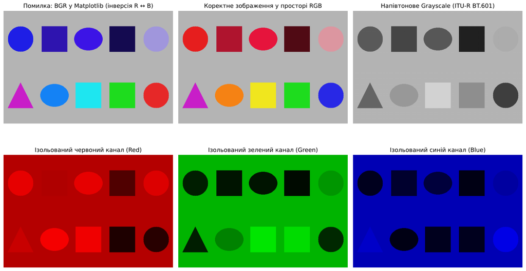

```python
img_cv = cv2.imread("data/test_image.png")                 # BGR
img_pil = Image.open("data/test_image.png")                # RGB
height, width, channels = img_cv.shape
total_pixels = height * width
memory_bytes = img_cv.nbytes
file_bytes = os.path.getsize("data/test_image.png")

img_rgb = cv2.cvtColor(img_cv, cv2.COLOR_BGR2RGB)
assert np.array_equal(np.asarray(img_pil), img_rgb)         # Pillow віддає RGB, збігається з cvtColor(BGR->RGB)
assert np.array_equal(img_cv[..., ::-1], img_rgb)           # BGR->RGB еквівалентно зворотному зрізу каналів

# Розділення каналів: cv2.split та зрізи NumPy
b_chan, g_chan, r_chan = cv2.split(img_cv)
assert np.array_equal(b_chan, img_cv[:, :, 0]) and np.array_equal(g_chan, img_cv[:, :, 1]) and np.array_equal(r_chan, img_cv[:, :, 2])

zeros_plane = np.zeros((height, width), dtype=np.uint8)
img_red_only = cv2.merge([zeros_plane, zeros_plane, r_chan])
img_green_only = cv2.merge([zeros_plane, g_chan, zeros_plane])
img_blue_only = cv2.merge([b_chan, zeros_plane, zeros_plane])

# Напівтонове зображення: OpenCV та ручний розрахунок за BT.601
img_gray = cv2.cvtColor(img_cv, cv2.COLOR_BGR2GRAY)
gray_manual = np.clip(np.rint(0.299 * r_chan + 0.587 * g_chan + 0.114 * b_chan), 0, 255).astype(np.uint8)
gray_diff = int(np.max(np.abs(img_gray.astype(int) - gray_manual.astype(int))))
assert gray_diff <= 1

# Інверсія каналів при показі BGR без перетворення: піксель червоного круга
cy, cx = 100, 60
bgr_px = img_cv[cy, cx]
print("=" * 82)
print("МЕТРИКИ ТА СТРУКТУРНІ ХАРАКТЕРИСТИКИ ТЕНЗОРА ЗОБРАЖЕННЯ")
print("=" * 82)
print(f"Роздільна здатність (Shape):     висота H = {height} px, ширина W = {width} px; кількість каналів: {channels}")
print(f"Загальна кількість пікселів:     {total_pixels:,} px")
print(f"Тип даних елементів:             {img_cv.dtype} (діапазон 0..255), {2 ** 8} градацій на канал")
print(f"Обсяг пам'яті (img.nbytes):      {memory_bytes:,} байт = {memory_bytes / 1024:.2f} КіБ; розмір PNG на диску: {file_bytes:,} байт (стиснення {memory_bytes / file_bytes:.1f}:1)")
print(f"Pillow:                          mode = {img_pil.mode}, size = {img_pil.size} (ширина, висота)")
print(f"Піксель червоного круга ({cy},{cx}):   OpenCV BGR = {tuple(int(v) for v in bgr_px)}; після cvtColor RGB = {tuple(int(v) for v in img_rgb[cy, cx])}")
print(f"  без перетворення у Matplotlib цей піксель інтерпретується як RGB = {tuple(int(v) for v in bgr_px)}, тобто майже чисто синій")
print(f"Канали: cv2.split збігається зі зрізами NumPy: True; BT.601: max|OpenCV - ручний| = {gray_diff} градація")
print("-" * 82)
print(f"{'Канал':<10}{'мінімум':>9}{'максимум':>10}{'середнє':>10}")
for nm, ch in [("B", b_chan), ("G", g_chan), ("R", r_chan), ("Gray", img_gray)]:
    print(f"{nm:<10}{int(ch.min()):9d}{int(ch.max()):10d}{ch.mean():10.2f}")
print("=" * 82)

fig, axes = plt.subplots(2, 3, figsize=(15, 9))
axes[0, 0].imshow(img_cv);                                  axes[0, 0].set_title("Помилка: BGR у Matplotlib (інверсія R ↔ B)")
axes[0, 1].imshow(img_rgb);                                 axes[0, 1].set_title("Коректне зображення у просторі RGB")
axes[0, 2].imshow(img_gray, cmap='gray', vmin=0, vmax=255); axes[0, 2].set_title("Напівтонове Grayscale (ITU-R BT.601)")
axes[1, 0].imshow(cv2.cvtColor(img_red_only, cv2.COLOR_BGR2RGB));   axes[1, 0].set_title("Ізольований червоний канал (Red)")
axes[1, 1].imshow(cv2.cvtColor(img_green_only, cv2.COLOR_BGR2RGB)); axes[1, 1].set_title("Ізольований зелений канал (Green)")
axes[1, 2].imshow(cv2.cvtColor(img_blue_only, cv2.COLOR_BGR2RGB));  axes[1, 2].set_title("Ізольований синій канал (Blue)")
for ax in axes.flat:
    ax.axis('off')
plt.tight_layout()
plt.savefig("figures/bgr_vs_rgb_channels.png", dpi=200)
plt.show()
```

## 4. Простори HSV та CIELab: перетворення, верифікація формул, аналіз каналів

Перетворення виконується `cv2.cvtColor` і одночасно реалізується вручну за формулами розділу 2 (HSV) та через $XYZ$ (CIELab). Розбіжності з OpenCV пояснюються цілочисельним округленням 8-бітного кодування. Для ахроматичних пікселів ($S=0$, сіре тло) колірний тон не визначений і за домовленістю дорівнює $0$, тому на карті каналу $H$ чистий червоний круг ($H=0$) візуально зливається з тлом: канал $H$ інформативний лише там, де $S>0$. Для оцінки перцептивної відмінності кольорів фігур використовується евклідова відстань у CIELab $\Delta E^*_{ab}=\sqrt{\Delta L^{*2}+\Delta a^{*2}+\Delta b^{*2}}$ (порівняно з відстанню в RGB).

```
Перевірка HSV: max|ручний - OpenCV| за H, S, V = [0, 0, 0] (градацій), точний збіг H: 100.00 %
Перевірка CIELab: max|ручний - OpenCV| за L, a, b = [0.48, 0.65, 0.61] (градацій 8-бітної шкали)

====================================================================================================
Фігура                                             BGR    H    S    V      L*      a*      b*
Чистий червоний (круг)                   (30, 30, 230)    0  222  230    49.3    71.1    52.8
Темно-червоний (прямокутник)             (46, 20, 175)  175  226  175    37.5    58.7    28.6
Малиново-червоний (еліпс)                (60, 20, 230)  174  233  230    49.1    73.4    36.5
Бордовий, V<100 (прямокутник)             (20, 10, 80)  176  223   80    15.3    31.9    14.2
Блідо-рожевий, S<120 (круг)            (160, 150, 220)  176   81  220    69.2    27.7     5.5
Пурпурний (трикутник)                   (200, 30, 200)  150  217  200    48.7    78.4   -48.8
Помаранчевий (еліпс)                    (20, 130, 245)   15  234  245    66.1    38.1    69.5
Жовтий (прямокутник)                    (30, 230, 240)   29  223  240    89.5   -15.4    85.1
Зелений (прямокутник)                    (30, 220, 30)   60  220  220    77.0   -74.8    70.8
Синій (круг)                             (230, 40, 40)  120  211  230    33.3    63.0   -92.0
====================================================================================================

Колірні відстані від цілі «Темно-червоний (прямокутник)»:
Об’єкт                                  ΔE*ab (CIELab)   евкл. RGB  |ΔH| (HSV, градацій)
Чистий червоний (круг)                            29.6        58.1                     5
Малиново-червоний (еліпс)                         20.3        56.8                     1
Бордовий, V<100 (прямокутник)                     37.7        99.0                     1
Блідо-рожевий, S<120 (круг)                       50.0       178.7                     1
Пурпурний (трикутник)                             80.6       156.3                    25
Помаранчевий (еліпс)                              54.0       133.0                    20
Жовтий (прямокутник)                             106.7       220.4                    34
Зелений (прямокутник)                            145.5       247.5                    65
Синій (круг)                                     120.8       229.1                    55
```

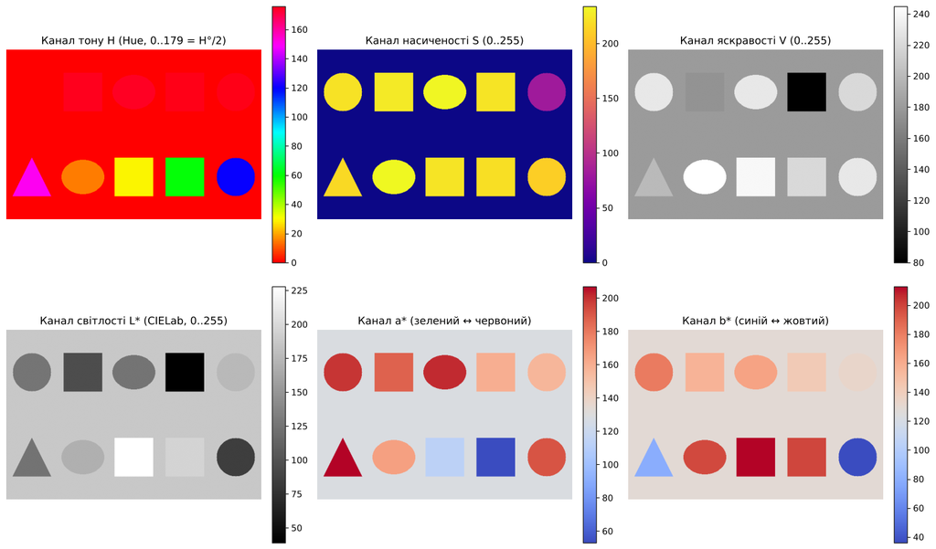

```python
img_hsv = cv2.cvtColor(img_cv, cv2.COLOR_BGR2HSV)
h_chan, s_chan, v_chan = cv2.split(img_hsv)
img_lab = cv2.cvtColor(img_cv, cv2.COLOR_BGR2Lab)
l_chan, a_chan, bl_chan = cv2.split(img_lab)

def bgr_to_hsv_manual(bgr):
    """HSV за формулами ЛБ: V = max, S = 1 - min/V, H за гілками; кодування OpenCV: H/2, S*255, V*255."""
    rgb = bgr[..., ::-1].astype(np.float64) / 255.0
    R, G, B = rgb[..., 0], rgb[..., 1], rgb[..., 2]
    V = rgb.max(-1); mn = rgb.min(-1); d = V - mn
    S = np.divide(d, V, out=np.zeros_like(V), where=V > 0)
    H = np.zeros_like(V)
    isr = (d > 0) & (V == R); isg = (d > 0) & (V == G) & ~isr; isb = (d > 0) & ~isr & ~isg
    H[isr] = (60.0 * (G - B)[isr] / d[isr]) % 360.0
    H[isg] = 60.0 * ((B - R)[isg] / d[isg] + 2.0)
    H[isb] = 60.0 * ((R - G)[isb] / d[isb] + 4.0)
    return H / 2.0, S * 255.0, V * 255.0

H_m, S_m, V_m = bgr_to_hsv_manual(img_cv)
d_hsv = [np.abs(np.rint(x) - y.astype(float)) for x, y in zip((H_m, S_m, V_m), (h_chan, s_chan, v_chan))]
print("Перевірка HSV: max|ручний - OpenCV| за H, S, V =", [int(x.max()) for x in d_hsv], "(градацій), точний збіг H: "
      f"{100 * np.mean(d_hsv[0] == 0):.2f} %")
assert all(x.max() <= 1 for x in d_hsv)

def bgr_to_lab_manual(bgr):
    """sRGB -> лінійний RGB -> XYZ (D65) -> CIELab; повертає L*, a*, b* у природних одиницях."""
    rgb = bgr[..., ::-1].astype(np.float64) / 255.0
    lin = np.where(rgb <= 0.04045, rgb / 12.92, ((rgb + 0.055) / 1.055) ** 2.4)
    M = np.array([[0.412453, 0.357580, 0.180423], [0.212671, 0.715160, 0.072169], [0.019334, 0.119193, 0.950227]])
    xyz = lin @ M.T / np.array([0.950456, 1.0, 1.088754])
    f = np.where(xyz > 0.008856, np.cbrt(xyz), 7.787 * xyz + 16.0 / 116.0)
    L = np.where(xyz[..., 1] > 0.008856, 116.0 * f[..., 1] - 16.0, 903.3 * xyz[..., 1])
    return L, 500.0 * (f[..., 0] - f[..., 1]), 200.0 * (f[..., 1] - f[..., 2])

L_m, a_m, b_m = bgr_to_lab_manual(img_cv)
d_lab = [np.abs(x - y.astype(float)) for x, y in zip((L_m * 255 / 100, a_m + 128, b_m + 128), (l_chan, a_chan, bl_chan))]
print("Перевірка CIELab: max|ручний - OpenCV| за L, a, b =", [round(float(x.max()), 2) for x in d_lab], "(градацій 8-бітної шкали)")
assert all(x.max() <= 2.0 for x in d_lab)

# --- Характеристики фігур у просторах HSV та CIELab та колірні відстані
print("\n" + "=" * 100)
print(f"{'Фігура':<38}{'BGR':>16}{'H':>5}{'S':>5}{'V':>5}{'L*':>8}{'a*':>8}{'b*':>8}")
shape_lab = []
for sh, m in zip(SHAPES, shape_masks):
    y_, x_ = np.argwhere(m > 0)[len(np.argwhere(m > 0)) // 2]
    hh, ss, vv = img_hsv[y_, x_]
    Lc, ac, bc = L_m[y_, x_], a_m[y_, x_], b_m[y_, x_]
    shape_lab.append((Lc, ac, bc))
    print(f"{sh['name']:<38}{str(sh['bgr']):>16}{int(hh):5d}{int(ss):5d}{int(vv):5d}{Lc:8.1f}{ac:8.1f}{bc:8.1f}")
print("=" * 100)

ref = 1  # темно-червоний прямокутник (ціль)
print(f"\nКолірні відстані від цілі «{SHAPES[ref]['name']}»:")
print(f"{'Об’єкт':<38}{'ΔE*ab (CIELab)':>16}{'евкл. RGB':>12}{'|ΔH| (HSV, градацій)':>22}")
rgb_ref = np.array(SHAPES[ref]['bgr'][::-1], float)
h_ref = int(img_hsv[np.argwhere(shape_masks[ref] > 0)[0][0], np.argwhere(shape_masks[ref] > 0)[0][1]][0])
delta_rows = {}
for i, sh in enumerate(SHAPES):
    if i == ref:
        continue
    pt = np.argwhere(shape_masks[i] > 0)[0]
    de = float(np.sqrt(sum((np.array(shape_lab[i]) - np.array(shape_lab[ref])) ** 2)))
    dr = float(np.linalg.norm(np.array(sh['bgr'][::-1], float) - rgb_ref))
    dh = int(min(abs(int(img_hsv[pt[0], pt[1]][0]) - h_ref), 180 - abs(int(img_hsv[pt[0], pt[1]][0]) - h_ref)))
    delta_rows[sh['name']] = (de, dr, dh)
    print(f"{sh['name']:<38}{de:16.1f}{dr:12.1f}{dh:22d}")

fig, axes = plt.subplots(2, 3, figsize=(15, 9))
specs = [(h_chan, 'hsv', "Канал тону H (Hue, 0..179 = H°/2)"), (s_chan, 'plasma', "Канал насиченості S (0..255)"),
         (v_chan, 'gray', "Канал яскравості V (0..255)"), (l_chan, 'gray', "Канал світлості L* (CIELab, 0..255)"),
         (a_chan, 'coolwarm', "Канал a* (зелений ↔ червоний)"), (bl_chan, 'coolwarm', "Канал b* (синій ↔ жовтий)")]
for ax, (ch, cmap, ttl) in zip(axes.flat, specs):
    im = ax.imshow(ch, cmap=cmap)
    ax.set_title(ttl); ax.axis('off')
    plt.colorbar(im, ax=ax, fraction=0.046, pad=0.04)
plt.tight_layout()
plt.savefig("figures/hsv_and_lab_spaces.png", dpi=200)
plt.show()
```

## 5. Порогова сегментація у просторі HSV (варіант 2)

Маска будується `cv2.inRange(img_hsv, lower, upper)`, цільові пікселі виділяються `cv2.bitwise_and(img, img, mask=mask)`. Для контрасту будується також маска доповнювального сектору Red Part 1 ($H\in[0,10]$) та об'єднана маска обох секторів (`cv2.bitwise_or`), яка була б необхідною для повного виявлення «червоного». Якість маски оцінюється кількісно: для кожної фігури визначається частка пікселів, що потрапили в маску, а загальна маска порівнюється з точною маскою цілей (`TP`, `FP`, `FN`, $\mathrm{IoU}$, $F_1$).

```
==========================================================================================
РЕЗУЛЬТАТИ КОЛІРНОЇ СЕГМЕНТАЦІЇ У ПРОСТОРІ HSV (варіант 2: H 170..180, S 120..255, V 100..255)
==========================================================================================
Маска варіанта 2:          площа =  14692 px ( 6.12 % кадру)
Еталонна маска цілей:      площа =  14692 px ( 6.12 % кадру)
Маска Red Part 1 (H 0..10): площа =   6361 px ( 2.65 % кадру) — чистий червоний круг, не ціль варіанта 2
Об'єднання обох секторів:  площа =  21053 px ( 8.77 % кадру)
TP = 14692, FP = 0, FN = 0; IoU = 1.0000; F1 = 1.0000
------------------------------------------------------------------------------------------
Фігура                                 площа, px  в масці, %    H    S    V   H✓ S✓ V✓   очікується
Чистий червоний (круг)                      6361         0.0    0  222  230    -   +   +    не вибрано
Темно-червоний (прямокутник)                8281       100.0  175  226  175    +   +   +    вибрано
Малиново-червоний (еліпс)                   6411       100.0  174  233  230    +   +   +    вибрано
Бордовий, V<100 (прямокутник)               8281         0.0  176  223   80    +   +   -    не вибрано
Блідо-рожевий, S<120 (круг)                 6361         0.0  176   81  220    +   -   +    не вибрано
Пурпурний (трикутник)                       4186         0.0  150  217  200    -   +   +    не вибрано
Помаранчевий (еліпс)                        6411         0.0   15  234  245    -   +   +    не вибрано
Жовтий (прямокутник)                        8281         0.0   29  223  240    -   +   +    не вибрано
Зелений (прямокутник)                       8281         0.0   60  220  220    -   +   +    не вибрано
Синій (круг)                                6361         0.0  120  211  230    -   +   +    не вибрано
==========================================================================================

Вплив шуму на чистий червоний круг (H = 0, G = B): розподіл пікселів між секторами червоного
  σ шуму   Red Part 1 (H 0..10), %   Red Part 2 (H 170..180), %   решта, %
       0                     100.0                          0.0        0.0
       2                      89.1                         10.9        0.0
       4                      73.2                         26.8        0.0
       8                      62.7                         37.3        0.0
```

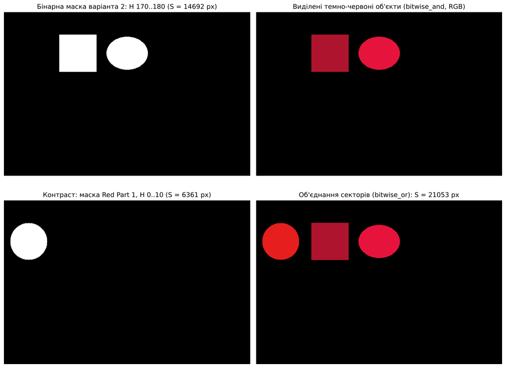

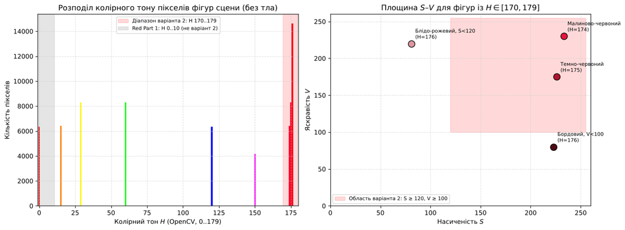

```python
# 1) Маска варіанта 2 та виділення об'єкта
mask_v2 = cv2.inRange(img_hsv, LOWER_RED2, UPPER_RED2)
res_v2_bgr = cv2.bitwise_and(img_cv, img_cv, mask=mask_v2)
res_v2_rgb = cv2.cvtColor(res_v2_bgr, cv2.COLOR_BGR2RGB)

# 2) Доповнювальний сектор Red Part 1 та об'єднання секторів
mask_r1 = cv2.inRange(img_hsv, LOWER_RED1, UPPER_RED1)
mask_union = cv2.bitwise_or(mask_v2, mask_r1)
res_union_rgb = cv2.cvtColor(cv2.bitwise_and(img_cv, img_cv, mask=mask_union), cv2.COLOR_BGR2RGB)

area_v2, area_r1, area_union = (cv2.countNonZero(m) for m in (mask_v2, mask_r1, mask_union))
area_gt = cv2.countNonZero(gt_target)

# 3) Точність відносно ефективної маски цілей
pred, gt = mask_v2 > 0, gt_target > 0
TP = int(np.sum(pred & gt)); FP = int(np.sum(pred & ~gt)); FN = int(np.sum(~pred & gt))
iou_v2 = TP / (TP + FP + FN); f1_v2 = 2 * TP / (2 * TP + FP + FN)

print("=" * 90)
print("РЕЗУЛЬТАТИ КОЛІРНОЇ СЕГМЕНТАЦІЇ У ПРОСТОРІ HSV (варіант 2: H 170..180, S 120..255, V 100..255)")
print("=" * 90)
print(f"Маска варіанта 2:          площа = {area_v2:6d} px ({100 * area_v2 / total_pixels:5.2f} % кадру)")
print(f"Еталонна маска цілей:      площа = {area_gt:6d} px ({100 * area_gt / total_pixels:5.2f} % кадру)")
print(f"Маска Red Part 1 (H 0..10): площа = {area_r1:6d} px ({100 * area_r1 / total_pixels:5.2f} % кадру) — чистий червоний круг, не ціль варіанта 2")
print(f"Об'єднання обох секторів:  площа = {area_union:6d} px ({100 * area_union / total_pixels:5.2f} % кадру)")
print(f"TP = {TP}, FP = {FP}, FN = {FN}; IoU = {iou_v2:.4f}; F1 = {f1_v2:.4f}")
print("-" * 90)
print(f"{'Фігура':<38}{'площа, px':>10}{'в масці, %':>12}{'H':>5}{'S':>5}{'V':>5}   H✓ S✓ V✓   очікується")
shape_table = []
for sh, m in zip(SHAPES, shape_masks):
    sel = int(np.sum((mask_v2 > 0) & (m > 0))); ar = int(cv2.countNonZero(m))
    pt = np.argwhere(m > 0)[0]; hh, ss, vv = (int(t) for t in img_hsv[pt[0], pt[1]])
    ok_h = LOWER_RED2[0] <= hh <= UPPER_RED2[0]; ok_s = LOWER_RED2[1] <= ss <= UPPER_RED2[1]; ok_v = LOWER_RED2[2] <= vv <= UPPER_RED2[2]
    print(f"{sh['name']:<38}{ar:10d}{100 * sel / ar:12.1f}{hh:5d}{ss:5d}{vv:5d}    {'+' if ok_h else '-'}   {'+' if ok_s else '-'}   {'+' if ok_v else '-'}    {'вибрано' if sh['target'] else 'не вибрано'}")
    assert (sel == ar) if sh['target'] else (sel == 0)
    shape_table.append(dict(name=sh['name'], bgr=list(sh['bgr']), area_px=ar, selected_pct=100 * sel / ar, H=hh, S=ss, V=vv,
                            H_ok=bool(ok_h), S_ok=bool(ok_s), V_ok=bool(ok_v), target=sh['target']))
print("=" * 90)
assert area_v2 == area_gt and FP == 0 and FN == 0 and area_union == area_v2 + area_r1

# --- Чистий червоний на межі кола тонів: вплив шуму (H = 0 ≡ 360°)
circle_mask = shape_masks[0] > 0
rng_n = np.random.default_rng(3)
wrap_rows = []
print("\nВплив шуму на чистий червоний круг (H = 0, G = B): розподіл пікселів між секторами червоного")
print(f"{'σ шуму':>8}{'Red Part 1 (H 0..10), %':>26}{'Red Part 2 (H 170..180), %':>29}{'решта, %':>11}")
for sg in (0, 2, 4, 8):
    noisy = np.clip(img_cv.astype(np.float32) + rng_n.normal(0, sg, img_cv.shape), 0, 255).astype(np.uint8)
    hs = cv2.cvtColor(noisy, cv2.COLOR_BGR2HSV)
    p1 = 100 * float(np.mean(cv2.inRange(hs, LOWER_RED1, UPPER_RED1)[circle_mask] > 0))
    p2 = 100 * float(np.mean(cv2.inRange(hs, LOWER_RED2, UPPER_RED2)[circle_mask] > 0))
    wrap_rows.append(dict(sigma=sg, red_part1_pct=p1, red_part2_pct=p2))
    print(f"{sg:8d}{p1:26.1f}{p2:29.1f}{max(0.0, 100 - p1 - p2):11.1f}")
cv2.imwrite("data/mask_variant2.png", mask_v2); cv2.imwrite("data/segmented_variant2.png", res_v2_bgr)

fig, axes = plt.subplots(2, 2, figsize=(13, 10))
axes[0, 0].imshow(mask_v2, cmap='gray'); axes[0, 0].set_title(f"Бінарна маска варіанта 2: H 170..180 (S = {area_v2} px)")
axes[0, 1].imshow(res_v2_rgb);           axes[0, 1].set_title("Виділені темно-червоні об'єкти (bitwise_and, RGB)")
axes[1, 0].imshow(mask_r1, cmap='gray'); axes[1, 0].set_title(f"Контраст: маска Red Part 1, H 0..10 (S = {area_r1} px)")
axes[1, 1].imshow(res_union_rgb);        axes[1, 1].set_title(f"Об'єднання секторів (bitwise_or): S = {area_union} px")
for ax in axes.flat:
    ax.axis('off')
plt.tight_layout()
plt.savefig("figures/hsv_color_segmentation.png", dpi=200)
plt.show()

# --- Обґрунтування меж: гістограма тону та площина S-V
obj_mask = np.zeros((H_IMG, W_IMG), bool)
for m in shape_masks:
    obj_mask |= m > 0
hue_hist = np.bincount(h_chan[obj_mask], minlength=180)
hue_rgb = cv2.cvtColor(np.stack([np.arange(180, dtype=np.uint8), np.full(180, 255, np.uint8), np.full(180, 255, np.uint8)], -1)[None], cv2.COLOR_HSV2RGB)[0] / 255.0

fig, axes = plt.subplots(1, 2, figsize=(14, 5.2))
ax = axes[0]
ax.bar(np.arange(180), hue_hist, color=hue_rgb, width=1.0)
ax.axvspan(LOWER_RED2[0] - 0.5, 179.5, color='red', alpha=0.15, label='Діапазон варіанта 2: H 170..179')
ax.axvspan(-0.5, UPPER_RED1[0] + 0.5, color='gray', alpha=0.2, label='Red Part 1: H 0..10 (не варіант 2)')
ax.set_title("Розподіл колірного тону пікселів фігур сцени (без тла)")
ax.set_xlabel("Колірний тон $H$ (OpenCV, 0..179)"); ax.set_ylabel("Кількість пікселів"); ax.set_xlim([-1, 180]); ax.grid(True); ax.legend(loc='upper center', fontsize=8)

ax = axes[1]
sv_pts = []
for sh, m in zip(SHAPES, shape_masks):
    pt = np.argwhere(m > 0)[0]; hh, ss, vv = (int(t) for t in img_hsv[pt[0], pt[1]])
    if LOWER_RED2[0] <= hh <= UPPER_RED2[0]:
        ax.scatter(ss, vv, s=110, color=np.array(sh['bgr'][::-1]) / 255.0, edgecolor='black', zorder=3)
        ax.annotate(sh['name'].split(' (')[0] + f"\n(H={hh})", (ss, vv), textcoords='offset points', xytext=(6, 8), fontsize=8)
ax.add_patch(plt.Rectangle((LOWER_RED2[1], LOWER_RED2[2]), 255 - LOWER_RED2[1], 255 - LOWER_RED2[2], fill=True, color='red', alpha=0.15, label='Область варіанта 2: S ≥ 120, V ≥ 100'))
ax.set_title("Площина $S$–$V$ для фігур із $H\\in[170,179]$")
ax.set_xlabel("Насиченість $S$"); ax.set_ylabel("Яскравість $V$"); ax.set_xlim([0, 260]); ax.set_ylim([0, 260]); ax.grid(True); ax.legend(loc='lower left', fontsize=8)
plt.tight_layout()
plt.savefig("figures/hsv_threshold_justification.png", dpi=200)
plt.show()
```

## 6. Прикладна ілюстрація: крововиливи на синтетичному знімку та стійкість до експозиції

Сфера застосування варіанта — аналіз крововиливів. Синтезується знімок тканини $400\times600$: блідо-рожева тканина з низькочастотною текстурою, **крововиливи** — нерегулярні темно-червоні плями ($H\approx175$, що виділяє діапазон варіанта 2) із сателітами та тонкі **судини** яскраво-червоного кольору з відтінком у бік помаранчевого ($H\approx2$, сектор Red Part 1, не ціль). Еталонна маска крововиливів відома. Знімок згладжується (краї плям розмиті), множиться на коефіцієнт експозиції $k$ ($k<1$ — недосвітлення, $k>1$ — пересвічення; значення обмежуються діапазоном $[0,255]$) та спотворюється гаусовим шумом сенсора $\sigma=4$. Піксели в смузі $\pm2$ px навколо межі еталона виключаються з оцінки (розмиті краї не мають однозначної мітки).

Порівнюються три методи за метрикою $\mathrm{IoU}$ відносно еталона:

- **HSV-маска** з порогами варіанта 2;
- **RGB-маска** `R ≥ Rmin ∧ G ≤ Gmax ∧ B ≤ Bmax` із порогами, **підібраними повним перебором** (за $\mathrm{IoU}$ відносно еталона) на номінальному знімку $k=1$ — навмисно «оракульна» (найсприятливіша для RGB) база;
- **HSV з послабленим $V_{min}=40$** — ілюстрація того, що в HSV для адаптації до експозиції достатньо змінити один параметр, а колірні межі $H,S$ лишаються тими самими.

У HSV експозиція впливає переважно на $V$ (хроматичні $H$, $S$ майже не змінюються), у RGB вона змінює всі три канали одночасно, тому колірні порогові умови, налаштовані для одного рівня світла, перестають працювати на іншому.

```
Площа крововиливів (еталон): 11631 px (4.85 % кадру); смуга, виключена з оцінки: 6472 px; пікселів судин (поза плямами): 5249
```

```
Оптимальні RGB-пороги на k = 1: R ≥ 60, G ≤ 40, B ≤ 70 (IoU = 1.000)

    k  HSV: IoU   prec  recall  судини,%  RGB: IoU   prec  recall  судини,%  HSV Vmin=40
  0.4     0.000  0.000   0.000       0.0     0.633  0.634   0.996      94.5        0.841
  0.5     0.001  0.019   0.002      10.3     0.688  0.688   1.000      75.7        0.898
  0.6     0.854  0.936   0.907       7.5     0.736  0.736   1.000      60.0        0.935
  0.8     0.968  0.968   1.000       3.5     0.916  0.916   1.000      15.2        0.968
  1.0     0.981  0.981   1.000       1.6     1.000  1.000   1.000       0.1        0.981
  1.2     0.993  0.993   1.000       0.6     1.000  1.000   1.000       0.0        0.993
  1.4     0.998  0.998   1.000       0.3     0.915  1.000   0.915       0.0        0.998
  1.6     1.000  1.000   1.000       0.1     0.233  1.000   0.233       0.0        1.000

Судини (поза плямами): медіана H = 2; пікселів у секторі Red Part 1: 98.4 %; у діапазоні варіанта 2: 1.6 %
```

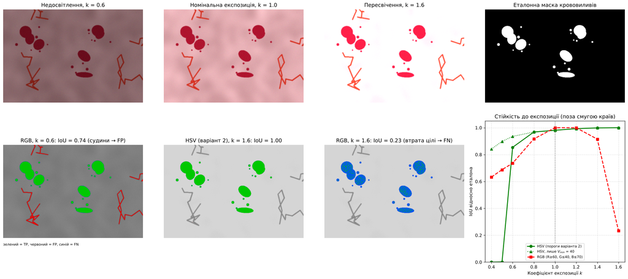

```python
def make_tissue(seed=5):
    """Синтетичний знімок тканини (float BGR): крововиливи (ціль), судини (яскраво-червоні, H ~ 2) та еталонна маска."""
    rng = np.random.default_rng(seed)
    tex = cv2.GaussianBlur(rng.normal(0, 1, (H_IMG, W_IMG)).astype(np.float32), (0, 0), 18)
    tex = tex / tex.std() * 7.0
    img = np.empty((H_IMG, W_IMG, 3), np.float32); img[:] = (175, 170, 225)       # блідо-рожева тканина (BGR)
    img += tex[..., None]
    vessel = np.zeros((H_IMG, W_IMG), np.uint8)
    for _ in range(4):                                                             # судини
        pts = np.cumsum(rng.normal(0, 25, (14, 2)), axis=0) + rng.uniform([50, 50], [550, 350], 2)
        cv2.polylines(vessel, [pts.astype(np.int32)], False, 255, 3)
    blob = np.zeros((H_IMG, W_IMG), np.uint8)
    for _ in range(7):                                                             # крововиливи
        c = rng.uniform([60, 60], [540, 340]).astype(int)
        cv2.ellipse(blob, tuple(int(v) for v in c), (int(rng.integers(14, 38)), int(rng.integers(9, 26))), float(rng.uniform(0, 180)), 0, 360, 255, -1)
        for _ in range(int(rng.integers(2, 5))):                                   # сателіти
            off = c + rng.normal(0, 38, 2).astype(int)
            cv2.circle(blob, tuple(int(v) for v in off), int(rng.integers(3, 7)), 255, -1)
    img = np.where(vessel[..., None] > 0, np.array((35, 50, 215), np.float32) + rng.normal(0, 3, (H_IMG, W_IMG, 3)), img)
    img = np.where(blob[..., None] > 0, np.array((46, 20, 175), np.float32) + rng.normal(0, 4, (H_IMG, W_IMG, 3)), img)
    img = cv2.GaussianBlur(img.astype(np.float32), (0, 0), 1.0)                    # розмиті краї плям
    return img, blob, vessel

def render(img_f, k, seed=11):
    """Експозиція k та шум сенсора sigma = 4 (значення обмежуються до [0, 255])."""
    out = img_f * k + np.random.default_rng(seed).normal(0, 4, img_f.shape)
    return np.clip(np.rint(out), 0, 255).astype(np.uint8)

def seg_metrics(pred, gt, valid=None):
    """TP/FP/FN та похідні метрики; піксели поза маскою valid (смуга розмитих країв) виключаються з оцінки."""
    pred, gt = pred > 0, gt > 0
    if valid is not None:
        pred, gt = pred & valid, gt & valid
    tp = np.sum(pred & gt); fp = np.sum(pred & ~gt); fn = np.sum(~pred & gt)
    return dict(precision=float(tp / max(tp + fp, 1)), recall=float(tp / max(tp + fn, 1)), iou=float(tp / max(tp + fp + fn, 1)), f1=float(2 * tp / max(2 * tp + fp + fn, 1)))

tissue_f, gt_blob, vessel_mask = make_tissue()
img_t0 = render(tissue_f, 1.0)
cv2.imwrite("data/hemorrhage_scene.png", img_t0); cv2.imwrite("data/hemorrhage_ground_truth.png", gt_blob)

# Смуга ±2 px навколо межі еталона виключається з оцінки (don't-care)
k5 = np.ones((5, 5), np.uint8)
band = cv2.subtract(cv2.dilate(gt_blob, k5), cv2.erode(gt_blob, k5))
valid = band == 0
vessel_only = (vessel_mask > 0) & (cv2.dilate(gt_blob, np.ones((15, 15), np.uint8)) == 0)     # судини, віддалені від плям
print(f"Площа крововиливів (еталон): {cv2.countNonZero(gt_blob)} px ({100 * cv2.countNonZero(gt_blob) / (H_IMG * W_IMG):.2f} % кадру); "
      f"смуга, виключена з оцінки: {int(band.astype(bool).sum())} px; пікселів судин (поза плямами): {int(vessel_only.sum())}")

# --- Оптимальні RGB-пороги на номінальній експозиції k = 1 (повний перебір за IoU)
Bc, Gc, Rc = (img_t0[..., i].astype(np.int16) for i in range(3))
R_ge = {t: Rc >= t for t in range(60, 211, 10)}
G_le = {t: Gc <= t for t in range(10, 151, 10)}
B_le = {t: Bc <= t for t in range(30, 171, 10)}
best, rgb_thr = -1.0, None
for tr, mr in R_ge.items():
    for tg, mg in G_le.items():
        mrg = mr & mg
        for tb, mb in B_le.items():
            iou_ = seg_metrics(mrg & mb, gt_blob, valid)['iou']
            if iou_ > best:
                best, rgb_thr = iou_, (tr, tg, tb)
print(f"Оптимальні RGB-пороги на k = 1: R ≥ {rgb_thr[0]}, G ≤ {rgb_thr[1]}, B ≤ {rgb_thr[2]} (IoU = {best:.3f})")

LOWER_V40 = np.array([170, 120, 40], dtype=np.uint8)           # той самий колірний діапазон, послаблено лише V_min
def seg_hsv(img, lower=LOWER_RED2): return cv2.inRange(cv2.cvtColor(img, cv2.COLOR_BGR2HSV), lower, UPPER_RED2)
def seg_rgb(img): return (((img[..., 2] >= rgb_thr[0]) & (img[..., 1] <= rgb_thr[1]) & (img[..., 0] <= rgb_thr[2])) * 255).astype(np.uint8)

k_list = [0.4, 0.5, 0.6, 0.8, 1.0, 1.2, 1.4, 1.6]
rows = []
print(f"\n{'k':>5}{'HSV: IoU':>10}{'prec':>7}{'recall':>8}{'судини,%':>10}{'RGB: IoU':>10}{'prec':>7}{'recall':>8}{'судини,%':>10}{'HSV Vmin=40':>13}")
for k in k_list:
    im_k = render(tissue_f, k)
    ph, pr, p40 = seg_hsv(im_k), seg_rgb(im_k), seg_hsv(im_k, LOWER_V40)
    mh, mr_, m40 = (seg_metrics(x, gt_blob, valid) for x in (ph, pr, p40))
    vh, vr = 100 * float(np.mean(ph[vessel_only] > 0)), 100 * float(np.mean(pr[vessel_only] > 0))
    rows.append(dict(k=k, hsv=mh, rgb=mr_, hsv_vmin40=m40, vessel_in_mask_hsv_pct=vh, vessel_in_mask_rgb_pct=vr))
    print(f"{k:5.1f}{mh['iou']:10.3f}{mh['precision']:7.3f}{mh['recall']:8.3f}{vh:10.1f}{mr_['iou']:10.3f}{mr_['precision']:7.3f}{mr_['recall']:8.3f}{vr:10.1f}{m40['iou']:13.3f}")

hsv_t0 = cv2.cvtColor(img_t0, cv2.COLOR_BGR2HSV)
v_h = hsv_t0[..., 0][vessel_only]
print(f"\nСудини (поза плямами): медіана H = {np.median(v_h):.0f}; пікселів у секторі Red Part 1: {100 * np.mean(v_h <= 10):.1f} %; у діапазоні варіанта 2: {100 * np.mean(v_h >= 170):.1f} %")

def overlay(base_bgr, pred, gt):
    out = cv2.cvtColor(cv2.cvtColor(base_bgr, cv2.COLOR_BGR2GRAY), cv2.COLOR_GRAY2RGB).astype(np.float32) * 0.6 + 60
    p, t = pred > 0, gt > 0
    for cond, col in [(p & t, (0, 200, 0)), (p & ~t, (230, 0, 0)), (~p & t, (0, 80, 255))]:
        out[cond] = col
    return np.clip(out, 0, 255).astype(np.uint8)

K_DIM, K_BRIGHT = 0.6, 1.6
img_dim, img_bright = render(tissue_f, K_DIM), render(tissue_f, K_BRIGHT)
iou_of = lambda pred: seg_metrics(pred, gt_blob, valid)['iou']
fig, axes = plt.subplots(2, 4, figsize=(20, 9.5))
axes[0, 0].imshow(cv2.cvtColor(img_dim, cv2.COLOR_BGR2RGB));    axes[0, 0].set_title(f"Недосвітлення, k = {K_DIM}")
axes[0, 1].imshow(cv2.cvtColor(img_t0, cv2.COLOR_BGR2RGB));     axes[0, 1].set_title("Номінальна експозиція, k = 1.0")
axes[0, 2].imshow(cv2.cvtColor(img_bright, cv2.COLOR_BGR2RGB)); axes[0, 2].set_title(f"Пересвічення, k = {K_BRIGHT}")
axes[0, 3].imshow(gt_blob, cmap='gray');                        axes[0, 3].set_title("Еталонна маска крововиливів")
axes[1, 0].imshow(overlay(img_dim, seg_rgb(img_dim), gt_blob));       axes[1, 0].set_title(f"RGB, k = {K_DIM}: IoU = {iou_of(seg_rgb(img_dim)):.2f} (судини → FP)")
axes[1, 1].imshow(overlay(img_bright, seg_hsv(img_bright), gt_blob)); axes[1, 1].set_title(f"HSV (варіант 2), k = {K_BRIGHT}: IoU = {iou_of(seg_hsv(img_bright)):.2f}")
axes[1, 2].imshow(overlay(img_bright, seg_rgb(img_bright), gt_blob)); axes[1, 2].set_title(f"RGB, k = {K_BRIGHT}: IoU = {iou_of(seg_rgb(img_bright)):.2f} (втрата цілі → FN)")
for ax in list(axes[0]) + list(axes[1, :3]):
    ax.axis('off')
axes[1, 0].text(0.0, -0.08, "зелений = TP, червоний = FP, синій = FN", transform=axes[1, 0].transAxes, fontsize=8)
ax = axes[1, 3]
ax.plot(k_list, [r['hsv']['iou'] for r in rows], 'go-', lw=2, label='HSV (пороги варіанта 2)')
ax.plot(k_list, [r['hsv_vmin40']['iou'] for r in rows], 'g^:', lw=1.5, label='HSV, лише $V_{min}$ = 40')
ax.plot(k_list, [r['rgb']['iou'] for r in rows], 'rs--', lw=2, label=f'RGB (R≥{rgb_thr[0]}, G≤{rgb_thr[1]}, B≤{rgb_thr[2]})')
ax.axvline(1.0, color='gray', ls=':')
ax.set_title("Стійкість до експозиції (поза смугою країв)"); ax.set_xlabel("Коефіцієнт експозиції $k$"); ax.set_ylabel("IoU відносно еталона")
ax.set_ylim([0, 1.05]); ax.grid(True); ax.legend(fontsize=8, loc='lower center')
plt.tight_layout()
plt.savefig("figures/hemorrhage_application.png", dpi=200)
plt.show()
```

## 7. Експорт результатів

```python
import csv
with open("data/shape_table.csv", "w", newline="", encoding="utf-8") as f:
    w = csv.DictWriter(f, fieldnames=list(shape_table[0].keys()))
    w.writeheader(); w.writerows(shape_table)

results = dict(
    variant=2,
    thresholds=dict(lower=LOWER_RED2.tolist(), upper=UPPER_RED2.tolist(), complementary_red_part1=dict(lower=LOWER_RED1.tolist(), upper=UPPER_RED1.tolist())),
    tensor=dict(shape=[height, width, channels], dtype=str(img_cv.dtype), pixels=total_pixels, nbytes=memory_bytes,
                nbytes_kib=memory_bytes / 1024, png_file_bytes=file_bytes, pillow_mode=img_pil.mode, pillow_size=list(img_pil.size)),
    verification=dict(gray_max_diff=gray_diff, hsv_max_diff=[int(x.max()) for x in d_hsv], lab_max_diff=[float(x.max()) for x in d_lab]),
    segmentation=dict(area_variant2_px=area_v2, area_variant2_pct=100 * area_v2 / total_pixels, area_ground_truth_px=area_gt,
                      area_red_part1_px=area_r1, area_union_px=area_union, TP=TP, FP=FP, FN=FN, IoU=iou_v2, F1=f1_v2),
    delta_e_from_target={k: dict(deltaE_ab=v[0], rgb_distance=v[1], hue_difference=v[2]) for k, v in delta_rows.items()},
    hue_wrap_pure_red=wrap_rows,
    hemorrhage=dict(ground_truth_px=int(cv2.countNonZero(gt_blob)), rgb_thresholds=list(rgb_thr), exposure_sweep=rows),
)
with open("data/results.json", "w", encoding="utf-8") as f:
    json.dump(results, f, ensure_ascii=False, indent=1, default=float)
print("Готово: figures/, data/")
```

```
Готово: figures/, data/
```

## Контрольні питання:

### 1. Як влаштоване представлення кольорового цифрового зображення у вигляді тривимірного тензора в бібліотеці NumPy, і що визначає кожен із трьох індексів $I[y, x, c]$?

У бібліотеці NumPy кольорове цифрове зображення представляється як тривимірний масив (`ndarray`) розмірністю $(H, W, C)$, де $H$ — висота зображення в пікселях, $W$ — ширина, а $C$ — кількість колірних каналів (зазвичай $C = 3$, стандартний тип даних — `uint8` зі значеннями від $0$ до $255$). Кожен із трьох індексів тензора $I[y, x, c]$ визначає:

- $y \in [0, H-1]$ — вертикальну координату пікселя (індекс рядка, відлік ведеться зверху вниз);
- $x \in [0, W-1]$ — горизонтальну координату пікселя (індекс стовпця, відлік ведеться зліва направо);
- $c \in [0, C-1]$ — індекс колірного каналу (наприклад, для простору BGR: $0$ — синій, $1$ — зелений, $2$ — червоний).

### 2. Чому при читанні файлу зображення засобами OpenCV використовується порядок каналів $\text{BGR}$, і які спотворення виникають при спробі його безпосереднього відображення бібліотекою Matplotlib?

Порядок каналів $\text{BGR}$ в OpenCV склався історично: на момент створення бібліотеки наприкінці 1990-х років такий порядок байтів у пам'яті був стандартом для багатьох виробників відеокамер, апаратних відеодекодерів та графічної підсистеми Windows (зокрема формату BMP).

Оскільки бібліотека Matplotlib працює зі стандартним порядком $\text{RGB}$, при безпосередньому відображенні $\text{BGR}$-масиву відбувається інверсія червоного та синього каналів: червоні об'єкти на зображенні стають синіми, а сині — червоними (наприклад, відтінки шкіри набувають неприродного синюватого кольору). Для коректного виведення необхідно попередньо конвертувати масив функцією `cv2.cvtColor(img, cv2.COLOR_BGR2RGB)`.

### 3. За якою математичною залежністю здійснюється перетворення кольорового $\text{RGB}$-зображення у монохромне напівтонове (Grayscale) за стандартом $\text{ITU-R BT.601}$, і чому вага зеленого каналу є найбільшою?

За стандартом $\text{ITU-R BT.601}$ яскравість напівтонового пікселя ($Y$) обчислюється як зважена лінійна комбінація інтенсивностей трьох колірних каналів:

$$Y = 0.299 \cdot R + 0.587 \cdot G + 0.114 \cdot B$$

Вага зеленого каналу ($0.587$) є найбільшою через фізіологічні особливості людського зору: фоторецептори сітківки ока (колбочки) мають найвищу спектральну чутливість саме до хвиль середньої довжини (зелено-жовтого діапазону спектра, близько $555\text{ нм}$), тому зелений компонент робить найбільший внесок у суб'єктивне сприйняття яскравості.

### 4. У чому полягає геометрична структура та фізичний зміст компонентів циліндричного колірного простору $\text{HSV}$ (Hue, Saturation, Value)?

Геометрично простір $\text{HSV}$ представляється у вигляді тривимірного циліндра (або перевернутого конуса), де колір задається в циліндричних координатах:

- **Hue ($H$, колірний тон)** — кутова координата навколо центральної осі ($0^\circ \dots 360^\circ$), що визначає базовий спектральний колір (домінуючу довжину хвилі: $0^\circ$ — червоний, $120^\circ$ — зелений, $240^\circ$ — синій);
- **Saturation ($S$, насиченість)** — радіальна відстань від центральної ахроматичної осі до бічної стінки циліндра ($0\% \dots 100\%$), що характеризує чистоту кольору (ступінь його розбавлення білим: $0$ — відтінок сірого, максимум — чистий колір);
- **Value ($V$, яскравість / значення)** — висота вздовж вертикальної осі ($0\% \dots 100\%$), що визначає загальну інтенсивність світла (від абсолютно чорного $0$ на нижній основі до максимальної яскравості на верхній).

### 5. Чому значення колірного тону $H$ в 8-бітній реалізації OpenCV обмежене діапазоном $[0, 180]$, і як правильно виконати сегментацію об'єктів червоного кольору, сектор яких розривається на межі $0^\circ$ та $360^\circ$?

Стандартний кутовий діапазон колірного тону становить $[0^\circ, 360^\circ)$, але максимальне значення, яке здатне зберігати 8-бітне беззнакове ціле число (`uint8`), дорівнює $255$. Щоб умістити повне коло без втрати цілочисельного типу даних, в OpenCV кут ділиться навпіл ($H_{\text{OpenCV}} = H / 2$), завдяки чому його значення обмежуються діапазоном $[0, 180]$.

Оскільки червоний колір в OpenCV займає два розірвані інтервали — на початку шкали (орієнтовно $[0, 10]$) та в її кінці (орієнтовно $[170, 180]$), — правильна сегментація виконується у два кроки:

1. Окремо створюються дві бінарні маски за допомогою `cv2.inRange()` для нижнього та верхнього діапазонів червоного кольору;
2. Маски об'єднуються логічним додаванням («АБО») за допомогою функції `cv2.bitwise_or(mask1, mask2)`.

### 6. Які переваги надає рівноконтрастний колірний простір $\text{CIELab}$ ($L^*a^*b^*$) порівняно з простором $\text{RGB}$ при оцінці колірних відмінностей ($\Delta E$)?

Порівняно з $\text{RGB}$, простір $\text{CIELab}$ має такі ключові переваги при оцінці колірних відмінностей:

- **Перцептивна однорідність (рівноконтрастність):** евклідова відстань між двома точками у просторі $\text{CIELab}$ ($\Delta E = \sqrt{(\Delta L^*)^2 + (\Delta a^*)^2 + (\Delta b^*)^2}$) лінійно відповідає візуальній різниці, яку сприймає людське око. У нелінійному просторі $\text{RGB}$ однакова геометрична відстань у різних ділянках куба сприймається людиною нерівномірно.
- **Відокремлення яскравості від хроматичності:** канал $L^*$ відповідає виключно за світлоту, тоді як канали $a^*$ (зелений–червоний) та $b^*$ (синій–жовтий) описують колірний тон, що робить порівняння кольорів стійкішим до нерівномірного освітлення.
- **Апаратна незалежність:** координати $\text{CIELab}$ прив'язані до характеристик стандартного спостерігача (CIE), а не до конкретного дисплея чи сенсора камери.

### 7. Яким чином побітові логічні операції (`cv2.bitwise_and`) взаємодіють із бінарними масками для просторової фільтрації та вилучення цільових сегментів зображення?

Бінарна маска — це одноканальне 8-бітне зображення такого самого розміру, що й оригінал, де пікселі цільової області мають значення $255$ (у двійковому вигляді `11111111`), а фону — $0$ (`00000000`).

При виклику `cv2.bitwise_and(img, img, mask=mask)` побітова кон'юнкція (`AND`) застосовується до кожного пікселя та кожного колірного каналу вихідного зображення лише там, де відповідний піксель маски не дорівнює нулю:

- Якщо значення пікселя маски становить `11111111` ($255$), операція `pixel AND 11111111` залишає початкові біти інтенсивності пікселя без змін;
- Якщо значення пікселя маски становить `00000000` ($0$), операція `pixel AND 00000000` обнуляє всі біти, перетворюючи піксель на абсолютно чорний ($0$).

Таким чином на виході залишаються лише пікселі цільового сегмента (області інтересу), а весь інший простір заповнюється чорним фоном.